# 🔎A High-Frequency Word Analysis

### Author: Daeun Lee

```r
trueData <- read.csv("trueData.csv")
fakeData <- read.csv("fakeData.csv")
```

```r
library(dplyr)
library(ggplot2)
```

```r
common <- inner_join(trueData, fakeData, by = "word")
head(common, 5)
```

```
##           word freq.x article_count.x rank.x freq.y article_count.y rank.y
## 1          u s  43501            1490      1  17491            1042      4
## 2 united state  20353            9662      2  12360            6819      8
## 3          one  18225           23535      3  20593           28763      2
## 4         said  17665           30168      4  18478           18720      3
## 5 donald trump  14442           11958      6  20761           11694      1
```

From my initial analysis, I suspected that words commonly found in both genuine and fabricated articles would not be meaningful in distinguishing between them. As a result, I intend to exclude them from consideration and focus solely on the words that appear exclusively in each category.

```r
not_common_true <- anti_join(trueData, fakeData, by="word")
not_common_fake <- anti_join(fakeData, trueData, by="word")
```

I extracted the words that were unique to each category of true and fake articles and used them to generate a dataset of meaningful words. These words will enable me to distinguish between genuine and fabricated articles with greater accuracy.

```r
not_common_true
```

```
##                        word  freq article_count  rank
## 1                  mr trump 17408           127   5.0
## 2          president donald  6814          6677  27.0
## 3             islamic state  5822          2221  40.0
## 4               north korea  5791          1701  42.0
## 5            prime minister  5198          3591  52.0
## 6            said statement  4967          4213  57.0
## 7                    monday  4849          6856  60.0
## 8                   tuesday  4647          7865  66.0
## 9                    friday  4280          7231  81.0
## 10              mrs clinton  4149            15  92.0
## 11                wednesday  4138          7487  93.0
## 12                 thursday  3803          7464 118.0
## 13              s president  3798          4019 119.0
## 14               last month  3694          3139 128.0
```

[output cut: 123 more lines]

Above words were only occurred in true articles, which lead me to conclude that they tend to be true articles if they consist of the above words.

```r
not_common_fake
```

```
##                      word freq article_count  rank
## 1          featured image 7935          8398  18.0
## 2                       u 7219         43039  25.0
## 3             pic twitter 6931             5  30.0
## 4               image via 6531          6478  34.0
## 5              republican 5654          8833  45.0
## 6             getty image 4175          4061  90.0
## 7                    told 3955          8778 100.0
## 8                    t co 3812         17083 108.0
## 9                 https t 3693             0 116.0
## 10               election 3295          9204 145.5
## 11                   real 3219         14166 150.0
## 12              president 3210         17983 152.0
## 13                  watch 3143          8291 158.0
## 14                  obama 3122          9124 160.0
```

[output cut: 123 more lines]

Above words were only occurred in fake articles, which lead me to conclude that they tend to be fake articles if they consist of the above words.

```r
top6_not_common_true <- head(not_common_true, 6)
top6_not_common_fake <- head(not_common_fake, 6)
```

To gain a deeper understanding of the distinction between genuine and fabricated articles, I intend to create a visualization of the top six most frequent words from the generated dataset.

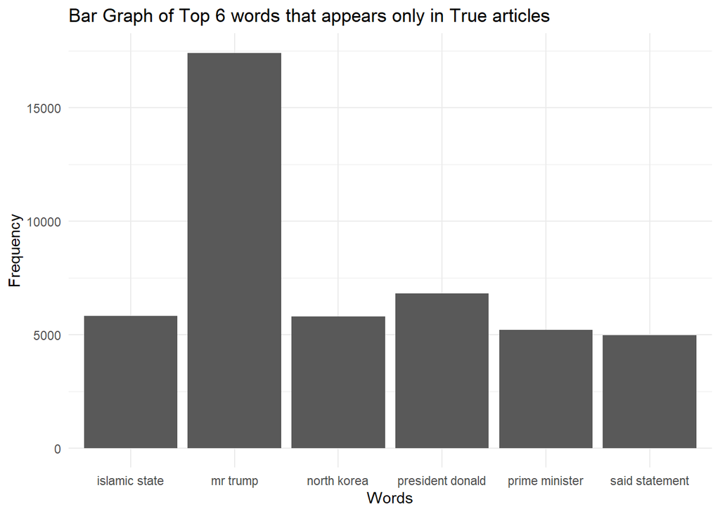

```r
ggplot(top6_not_common_true, aes(x = word, y = freq)) +
  geom_bar(stat = "identity") +
  theme_minimal() +
  labs(title = "Bar Graph of Top 6 words that appears only in True articles",
       x = "Words",
       y = "Frequency")
```

After analyzing the generated dataset, I was able to determine that the top six most frequent words did not appear in fake articles and were highly prevalent in genuine ones. Based on this finding, I can conclude that news articles containing formal phrases such as 'President Donald', 'Mr. Trump', 'Prime Minister', and 'said statement' - which suggest that journalist have conducted interviews or reported on official statements - are more likely to be authentic.

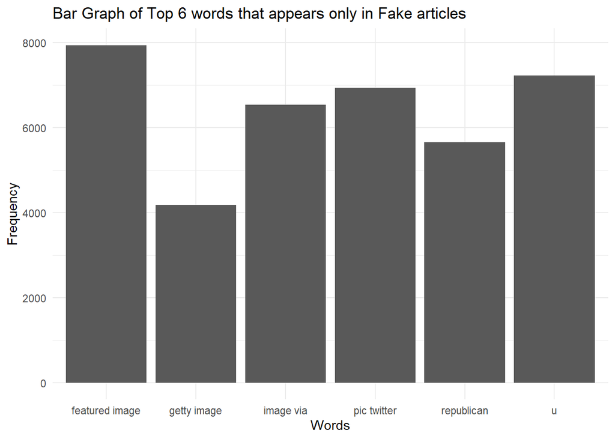

```r
ggplot(top6_not_common_fake, aes(x = word, y = freq)) +
  geom_bar(stat = "identity") +
  theme_minimal() +
  labs(title = "Bar Graph of Top 6 words that appears only in Fake articles",
       x = "Words",
       y = "Frequency")
```

I found that these six words did not appear in genuine articles but were highly frequent in fabricated ones. Among these words were 'getty image', which refers to a website for free image downloads, and 'pic twitter', another platform for image sharing. The inclusion of phrases such as 'featured image', 'getty image', 'image via', and 'pic twitter' suggests that the articles are likely to be fabricated, as they use images downloaded from the internet instead of those taken by the authors themselves.